# HW3

박찬영

2024-11-11

```r
library(tidyverse)
library(nycflights13)
library(babynames)
```

### Textbook 5.2.1 problem 2

Sketch out the process you’d use to calculate rate the for table2. You will need to perform four operations

1. Extract the number of TB cases per country per year.
2. Extract the matching population per country per year.
3. Divide cases by population, and multiply by 10000.
4. Store back in the appropriate place.

```r
cases <- table2 %>%
  filter(type == "cases") %>%
  .$count

population <- table2 %>%
  filter(type == "population") %>%
  .$count

rate <- cases / population * 10000

tidy_table2 <- table2 %>%
  mutate(rate = rep(rate, each = 2))

tidy_table2
```

```
## # A tibble: 12 × 5
##    country      year type            count  rate
##    <chr>       <dbl> <chr>           <dbl> <dbl>
##  1 Afghanistan  1999 cases             745 0.373
##  2 Afghanistan  1999 population   19987071 0.373
##  3 Afghanistan  2000 cases            2666 1.29
##  4 Afghanistan  2000 population   20595360 1.29
##  5 Brazil       1999 cases           37737 2.19
##  6 Brazil       1999 population  172006362 2.19
##  7 Brazil       2000 cases           80488 4.61
##  8 Brazil       2000 population  174504898 4.61
##  9 China        1999 cases          212258 1.67
## 10 China        1999 population 1272915272 1.67
## 11 China        2000 cases          213766 1.67
## 12 China        2000 population 1280428583 1.67
```

### Textbook 7.2.4 problem 5

Identify what is wrong with each of the following inline CSV files. What happens when you run the code?

```r
read_csv("a,b\n1,2,3\n4,5,6")
```

```
## # A tibble: 2 × 2
##       a     b
##   <dbl> <dbl>
## 1     1    23
## 2     4    56
```

```r
#변수의 수와 데이터의 수가 맞지않는다.
#a에 1, 4 b에 23, 56이 들어가 버린다.
read_csv("a,b,c\n1,2\n1,2,3,4")
```

```
## # A tibble: 2 × 3
##       a     b     c
##   <dbl> <dbl> <dbl>
## 1     1     2    NA
## 2     1     2    34
```

```r
#변수는 세개를 주었다. 그러나 첫번째 데이터는 1, 2만 주어서 c가 na가 됐다.
#그리고 두번째 값은 1,2,3,4를 줘서 c가 34가 되어버렸다.
read_csv("a,b\n\"1")
```

```
## # A tibble: 0 × 2
## # ℹ 2 variables: a <chr>, b <chr>
```

```r
#\"를 열기만 하고 닫지 않아서 1이라는 값이 읽히지 않는다.
read_csv("a,b\n1,2\na,b")
```

```
## # A tibble: 2 × 2
##   a     b
##   <chr> <chr>
## 1 1     2
## 2 a     b
```

```r
#마지막에 준 a,b가 각각의 데이터로 들어가서 전체 문자열 벡터 c("1", "a")와 c("2", "b")가 담기게 됐다.
#자료형이 안맞는 문제이다.
read_csv("a;b\n1;3")
```

```
## # A tibble: 1 × 1
##   `a;b`
##   <chr>
## 1 1;3
```

```r
#delimeter가 ,인데 ;으로 구분하여서 문제가 생겼다.
#a;b자체가 하나의 열이되고 1;3자체가 하나의 값이 되어버렸다.
```

### Textbook 19.3.4 problem 3

Does every departing flight have corresponding weather data for that hour?

```r
weather %>% summarise(sum(is.na(temp)))
```

```
## # A tibble: 1 × 1
##   `sum(is.na(temp))`
##                <int>
## 1                  1
```

```r
#weather 데이터의 temp 결측치는 1개이다.
flights %>%
  left_join(weather, by = c("origin", "year", "month", "day", "hour")) %>%
  select(origin, year, month, day, hour, temp) %>%
  summarise(sum(is.na(temp)))
```

```
## # A tibble: 1 × 1
##   `sum(is.na(temp))`
##                <int>
## 1               1573
```

```r
#flights와 weather를 origin과 시간을 기준으로 병합하였다.
#이때 temp의 결측치가 1573개 인 것으로 보아 모든 출발시간에 대응되는 날씨 데이터가 있지 않다.
```

### Textbook 14.2.4 problem 1

Create strings that contain the following values:

1. `He said "That's amazing!"`
2. `\a\b\c\d`
3. `\\\\\\`

```r
str <- c(
  "He said \"That's amazing!\"",
  "\\a\\b\\c\\d",
  "\\\\\\\\\\\\"
)
str_view(str)
```

```
## [1] │ He said "That's amazing!"
## [2] │ \a\b\c\d
## [3] │ \\\\\\
```

### Textbook 14.3.4 problem 1

Compare and contrast the results of `paste0()` with `str_c()` for the following inputs:

```r
str_c("hi ", NA)
```

```
## [1] NA
```

```r
#NA가 출력되어버린다.
#1 str_c(letters[1:2], letters[1:3])
#위 코드는 두 문자열 벡터의 크기가 맞지않아 컴바인이 안된다.
paste0("hi ", NA)
```

```
## [1] "hi NA"
```

```r
#NA마저 문자열로 합쳐버린다
paste0(letters[1:2], letters[1:3])
```

```
## [1] "aa" "bb" "ac"
```

```r
#벡터 반복으로 문자열 벡터끼리 붙인다.
```

### Textbook 15.3.5 problem 1

What baby name has the most vowels? What name has the highest proportion of vowels? (Hint: what is the denominator?)

```r
names <- babynames %>% distinct(name)
names %>%
  mutate(vowel = str_count(name, "[aeiouAEIOU]")) %>%
  mutate(prop = vowel / str_length(name)) %>%
  arrange(desc(prop))
```

```
## # A tibble: 97,310 × 3
##    name   vowel  prop
##    <chr>  <int> <dbl>
##  1 Eua        3 1
##  2 Ea         2 1
##  3 Ai         2 1
##  4 Ia         2 1
##  5 Ii         2 1
##  6 Aoi        3 1
##  7 Io         2 1
##  8 Aia        3 1
##  9 Alaiia     5 0.833
## 10 Amaiia     5 0.833
## # ℹ 97,300 more rows
```

```r
#Eua Ea Ai Ia Ii Aoi Io Aia 가 모음비율 100% 이름들이다
```

### Textbook 15.4.7 problem 3

Given the corpus of common words in `stringr::words`, create regular expressions that find all words that:

1. Start with “y”.
2. Don’t start with “y”.
3. End with “x”.
4. Are exactly three letters long. (Don’t cheat by using str_length()!)
5. Have seven letters or more.
6. Contain a vowel-consonant pair.
7. Contain at least two vowel-consonant pairs in a row.
8. Only consist of repeated vowel-consonant pairs.

```r
a <- str_subset(words, "^y")
a
```

```
## [1] "year"      "yes"       "yesterday" "yet"       "you"       "young"
```

```r
b <- str_subset(words, "^y", negate = TRUE)
b
```

```
##   [1] "a"           "able"        "about"       "absolute"    "accept"
##   [6] "account"     "achieve"     "across"      "act"         "active"
##  [11] "actual"      "add"         "address"     "admit"       "advertise"
##  [16] "affect"      "afford"      "after"       "afternoon"   "again"
##  [21] "against"     "age"         "agent"       "ago"         "agree"
##  [26] "air"         "all"         "allow"       "almost"      "along"
##  [31] "already"     "alright"     "also"        "although"    "always"
##  [36] "america"     "amount"      "and"         "another"     "answer"
##  [41] "any"         "apart"       "apparent"    "appear"      "apply"
##  [46] "appoint"     "approach"    "appropriate" "area"        "argue"
##  [51] "arm"         "around"      "arrange"     "art"         "as"
##  [56] "ask"         "associate"   "assume"      "at"          "attend"
##  [61] "authority"   "available"   "aware"       "away"        "awful"
##  [66] "baby"        "back"        "bad"         "bag"         "balance"
##  [71] "ball"        "bank"        "bar"         "base"        "basis"
```

[output cut: 180 more lines]

```r
c <- str_subset(words, "x$")
c
```

```
## [1] "box" "sex" "six" "tax"
```

```r
d <- str_subset(words, "^[a-zA-Z]{3}$")
d
```

```
##   [1] "act" "add" "age" "ago" "air" "all" "and" "any" "arm" "art" "ask" "bad"
##  [13] "bag" "bar" "bed" "bet" "big" "bit" "box" "boy" "bus" "but" "buy" "can"
##  [25] "car" "cat" "cup" "cut" "dad" "day" "die" "dog" "dry" "due" "eat" "egg"
##  [37] "end" "eye" "far" "few" "fit" "fly" "for" "fun" "gas" "get" "god" "guy"
##  [49] "hit" "hot" "how" "job" "key" "kid" "lad" "law" "lay" "leg" "let" "lie"
##  [61] "lot" "low" "man" "may" "mrs" "new" "non" "not" "now" "odd" "off" "old"
##  [73] "one" "out" "own" "pay" "per" "put" "red" "rid" "run" "say" "see" "set"
##  [85] "sex" "she" "sir" "sit" "six" "son" "sun" "tax" "tea" "ten" "the" "tie"
##  [97] "too" "top" "try" "two" "use" "war" "way" "wee" "who" "why" "win" "yes"
## [109] "yet" "you"
```

```r
e <- str_subset(words, "^[a-zA-Z]{7,}")
e
```

```
##   [1] "absolute"    "account"     "achieve"     "address"     "advertise"
##   [6] "afternoon"   "against"     "already"     "alright"     "although"
##  [11] "america"     "another"     "apparent"    "appoint"     "approach"
##  [16] "appropriate" "arrange"     "associate"   "authority"   "available"
##  [21] "balance"     "because"     "believe"     "benefit"     "between"
##  [26] "brilliant"   "britain"     "brother"     "business"    "certain"
##  [31] "chairman"    "character"   "Christmas"   "colleague"   "collect"
##  [36] "college"     "comment"     "committee"   "community"   "company"
##  [41] "compare"     "complete"    "compute"     "concern"     "condition"
##  [46] "consider"    "consult"     "contact"     "continue"    "contract"
##  [51] "control"     "converse"    "correct"     "council"     "country"
##  [56] "current"     "decision"    "definite"    "department"  "describe"
##  [61] "develop"     "difference"  "difficult"   "discuss"     "district"
##  [66] "document"    "economy"     "educate"     "electric"    "encourage"
##  [71] "english"     "environment" "especial"    "evening"     "evidence"
```

[output cut: 29 more lines]

```r
f <- str_subset(words, "[aeiou][^aeiou]")
f
```

```
##   [1] "able"        "about"       "absolute"    "accept"      "account"
##   [6] "achieve"     "across"      "act"         "active"      "actual"
##  [11] "add"         "address"     "admit"       "advertise"   "affect"
##  [16] "afford"      "after"       "afternoon"   "again"       "against"
##  [21] "age"         "agent"       "ago"         "agree"       "air"
##  [26] "all"         "allow"       "almost"      "along"       "already"
##  [31] "alright"     "also"        "although"    "always"      "america"
##  [36] "amount"      "and"         "another"     "answer"      "any"
##  [41] "apart"       "apparent"    "appear"      "apply"       "appoint"
##  [46] "approach"    "appropriate" "area"        "argue"       "arm"
##  [51] "around"      "arrange"     "art"         "as"          "ask"
##  [56] "associate"   "assume"      "at"          "attend"      "authority"
##  [61] "available"   "aware"       "away"        "awful"       "baby"
##  [66] "back"        "bad"         "bag"         "balance"     "ball"
##  [71] "bank"        "bar"         "base"        "basis"       "bear"
```

[output cut: 174 more lines]

```r
g <- str_subset(words, "([aeiou][^aeiou]){2,}")
g
```

```
##   [1] "absolute"    "agent"       "along"       "america"     "another"
##   [6] "apart"       "apparent"    "authority"   "available"   "aware"
##  [11] "away"        "balance"     "basis"       "become"      "before"
##  [16] "begin"       "behind"      "benefit"     "business"    "character"
##  [21] "closes"      "community"   "consider"    "cover"       "debate"
##  [26] "decide"      "decision"    "definite"    "department"  "depend"
##  [31] "design"      "develop"     "difference"  "difficult"   "direct"
##  [36] "divide"      "document"    "during"      "economy"     "educate"
##  [41] "elect"       "electric"    "eleven"      "encourage"   "environment"
##  [46] "europe"      "even"        "evening"     "ever"        "every"
##  [51] "evidence"    "exact"       "example"     "exercise"    "exist"
##  [56] "family"      "figure"      "final"       "finance"     "finish"
##  [61] "friday"      "future"      "general"     "govern"      "holiday"
##  [66] "honest"      "hospital"    "however"     "identify"    "imagine"
##  [71] "individual"  "interest"    "introduce"   "item"        "jesus"
```

[output cut: 19 more lines]

```r
h <- str_subset(words, "^([aeiou][^aeiou])+$")
h
```

```
##  [1] "as"       "at"       "away"     "eleven"   "even"     "ever"
##  [7] "if"       "in"       "it"       "item"     "of"       "okay"
## [13] "on"       "open"     "or"       "original" "over"     "unit"
## [19] "up"       "upon"
```

### Textbook 15.4.7 problem 4

Create 11 regular expressions that match the British or American spellings for each of the following words: airplane/aeroplane, aluminum/aluminium, analog/analogue, ass/arse, center/centre, defense/defence, donut/doughnut, gray/grey, modeling/modelling, skeptic/sceptic, summarize/summarise. Try and make the shortest possible regex!

```r
str_detect(c("airplane", "aeroplane"), "a(ir|ero)plane")
```

```
## [1] TRUE TRUE
```

```r
str_detect(c("aluminum", "aluminium"), "alumin(i?)um")
```

```
## [1] TRUE TRUE
```

```r
str_detect(c("analog", "analogue"), "analog(ue)?")
```

```
## [1] TRUE TRUE
```

```r
str_detect(c("ass", "arse"), "a(ss|rse)")
```

```
## [1] TRUE TRUE
```

```r
str_detect(c("defense", "defence"), "defen(s|c)e")
```

```
## [1] TRUE TRUE
```

```r
str_detect(c("donut", "doughnut"), "do(ugh)?nut")
```

```
## [1] TRUE TRUE
```

```r
str_detect(c("gray", "grey"), "gr(a|e)y")
```

```
## [1] TRUE TRUE
```

```r
str_detect(c("modeling", "modelling"), "modell?ing")
```

```
## [1] TRUE TRUE
```

```r
str_detect(c("skeptic", "sceptic"), "s(k|c)eptic")
```

```
## [1] TRUE TRUE
```

```r
str_detect(c("summarize", "summarise"), "summari(z|s)e")
```

```
## [1] TRUE TRUE
```

### Textbook 17.2.5 problem 3

For each of the following date-times, show how you’d parse it using a readr column specification and a lubridate function.

```r
d1 <- "January 1, 2010"
parse_date(d1, format = "%B %d, %Y")
```

```
## [1] "2010-01-01"
```

```r
mdy(d1)
```

[output not shown]

```r
d2 <- "2015-Mar-07"
parse_date(d2, format = "%Y-%b-%e")
```

```
## [1] "2015-03-07"
```

```r
ymd(d2)
```

```
## [1] "2015-03-07"
```

```r
d3 <- "06-Jun-2017"
parse_date(d3, "%e-%b-%Y")
```

```
## [1] "2017-06-06"
```

```r
dmy(d3)
```

```
## [1] "2017-06-06"
```

```r
d4 <- c("August 19 (2015)", "July 1 (2015)")
parse_date(d4, format = "%B %d (%Y)")
```

```
## [1] "2015-08-19" "2015-07-01"
```

```r
mdy(d4)
```

[output not shown]

```r
d5 <- "12/30/14" # Dec 30, 2014
parse_date(d5, "%m/%d/%y")
```

```
## [1] "2014-12-30"
```

```r
mdy(d5)
```

```
## [1] "2014-12-30"
```

```r
t1 <- "1705"
parse_time(t1, "%H%M")
```

```
## 17:05:00
```

```r
hm(as.double(t1) / 100)
```

```
## [1] "17H 5M 0S"
```

```r
t2 <- "11:15:10.12 PM"
parse_time(t2, format = "%H:%M:%OS %p")
```

```
## 23:15:10.12
```

```r
hms(t2) + hms("12:00:00")
```

```
## [1] "23H 15M 10.12S"
```

### Textbook 16.3.1 problem 1

Explore the distribution of `rincome` (reported income). What makes the default bar chart hard to understand? How could you improve the plot?

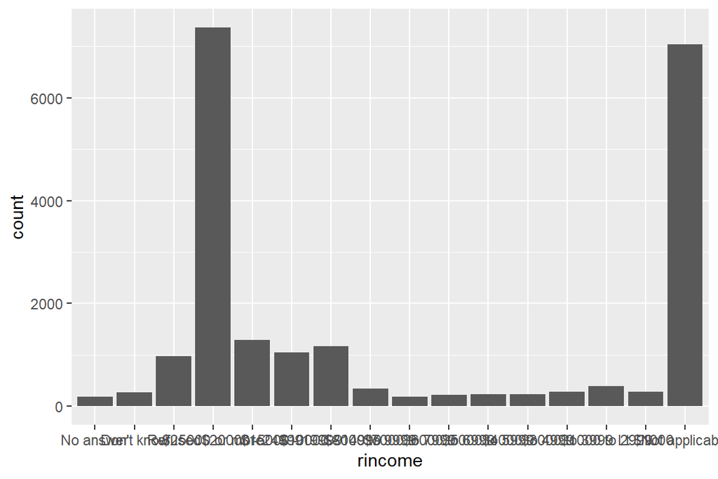

```r
gss_cat %>%
  ggplot(aes(x = rincome)) +
  geom_bar()
```

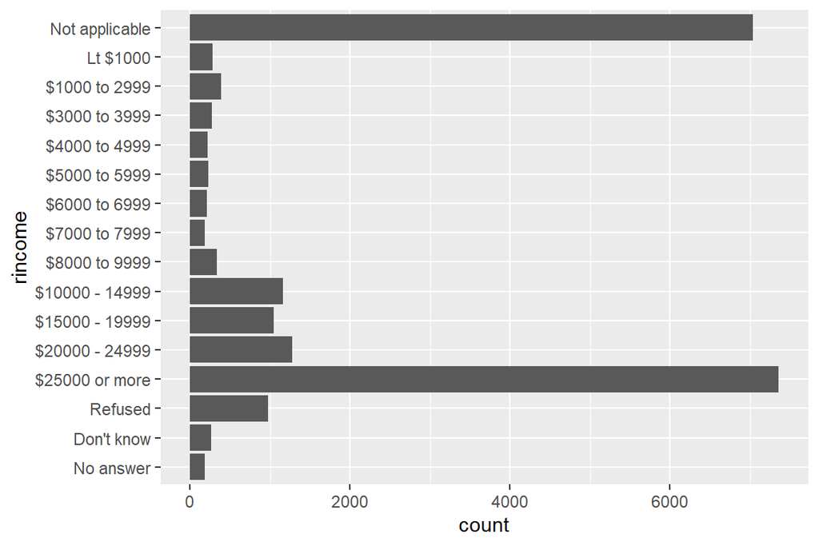

```r
#x축이 너무 타이트해서 보기힘듬.

gss_cat %>%
  ggplot(aes(y = rincome)) +
  geom_bar()
```

```r
#이러면 수준들이 잘 보인다.
```